# Paz Levi - Riskified

```python
import pandas as pd
import matplotlib.pyplot as plt
import seaborn as sns
```

```python
# read the Excel file
df = pd.read_excel('new_dataset_(4)_(1)_(1).xlsx')
df.head(5)
```

|  | order_id | order_date | order_status | price | digital_product | customer_account_age | order_source | billing_zip | shipping_name_length | classification_score |
| --- | --- | --- | --- | --- | --- | --- | --- | --- | --- | --- |
| 0 | 906967102 | 2019-06-01 | approved | 213.88 | False | 0 | web | 33062 | 13 | 0.999219 |
| 1 | 906987974 | 2019-06-01 | approved | 50.00 | True | 0 | mobile_app | 48317 | 0 | 0.995886 |
| 2 | 906994260 | 2019-06-01 | approved | 100.00 | True | 328 | web | 92124 | 0 | 0.966901 |
| 3 | 906997653 | 2019-06-01 | approved | 25.00 | True | 1371 | web | 95448 | 0 | 0.999854 |
| 4 | 907408483 | 2019-06-01 | approved | 2035.76 | False | 139 | web | 61107 | 17 | 0.999965 |

```python
#Check the column types
df.info()
```

```
<class 'pandas.core.frame.DataFrame'>
RangeIndex: 40825 entries, 0 to 40824
Data columns (total 10 columns):
 #   Column                Non-Null Count  Dtype
---  ------                --------------  -----
 0   order_id              40825 non-null  int64
 1   order_date            40825 non-null  datetime64[ns]
 2   order_status          40825 non-null  object
 3   price                 40825 non-null  float64
 4   digital_product       40825 non-null  bool
 5   customer_account_age  40825 non-null  int64
 6   order_source          40825 non-null  object
 7   billing_zip           40825 non-null  object
 8   shipping_name_length  40825 non-null  int64
 9   classification_score  40825 non-null  float64
dtypes: bool(1), datetime64[ns](1), float64(2), int64(3), object(3)
memory usage: 2.8+ MB
```

## Q1 - Set all values below the 90% threshold as 'decline' (in the rest of the questions I continued with the original table)

```python
df_cp = df.copy()
df_cp.loc[df['classification_score']<0.90,'order_status'] = 'decline'
```

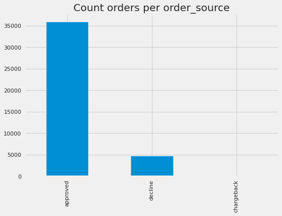

```python
df_cp['order_status'].value_counts().plot(kind='bar'),
plt.title("Count orders per order_source")
plt.show()
```

## Q2 - Plot the model scores distribution

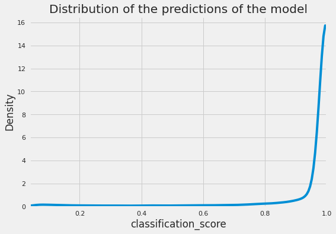

```python
plt.xlim(min(df['classification_score']),1)

sns.kdeplot(df['classification_score'])
plt.title("Distribution of the predictions of the model")

plt.show()
```

## Q3

**Given**:

CHB's / Total_revenue = 0.5 (50%)

I calculated the percentage of total revenue in relation to the sum of all orders

I summed up all the chargebacks that exist in the data to find the total revenue

```python
CHB = sum(df[df['order_status'] =='chargeback']['price'])
TR = CHB * 2
fee = TR/sum(df['price']) * 100
print(f"The fee is { fee} %")
```

```
The fee is 0.6015218197353748 %
```

## Q4

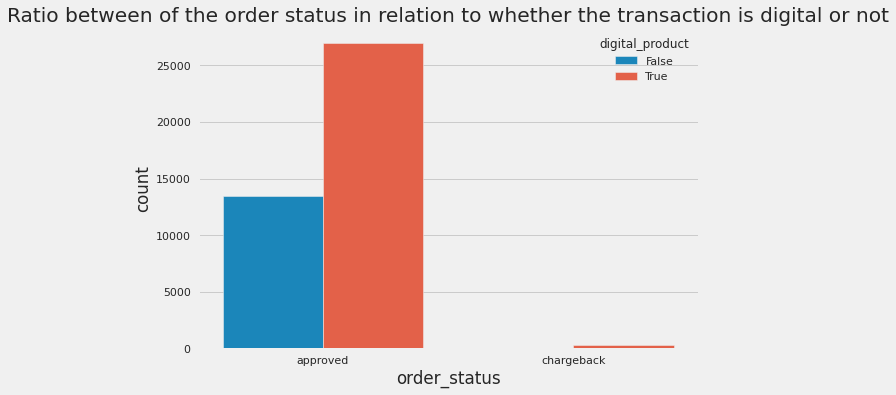

```python
plt.title("Ratio between of the order status in relation to whether the transaction is digital or not")
sns.countplot(x=df['order_status'],hue=df['digital_product'])
plt.show()
```

[figure not shown]

```python
plt.title("Ratio between of prediction of the model in relation to whether the transaction is digital or not")
sns.countplot(x=df['digital_product'],hue=df['classification_score']> 0.9)
plt.show()
```

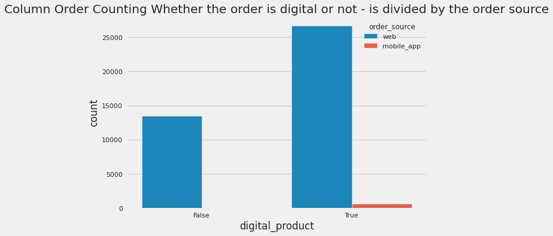

```python
sns.countplot(x=df['digital_product'],hue=df['order_source'])
plt.title("Column Order Counting Whether the order is digital or not - is divided by the order source")
plt.show()
```

**Use one label encoding to make all columns numeric (I removed the zip because I did not find use for this column)**

```python
df_new = df.copy()
print('The columns I made them one label encoding to make them numeric:\n')
for i in df.drop('billing_zip',axis=1).columns[2:]:
  if df[i].dtype == 'object' or  df[i].dtype =='bool':
    print(i)
    df_new=pd.concat([df_new,pd.get_dummies(df[[i]])],axis=1).drop(i,axis=1)
```

```
The columns I made them one label encoding to make them numeric:

order_status
digital_product
order_source
```

```python
df_new.head(4)
```

|  | order_id | order_date | price | customer_account_age | billing_zip | shipping_name_length | classification_score | order_status_approved | order_status_chargeback | order_source_mobile_app | order_source_web |
| --- | --- | --- | --- | --- | --- | --- | --- | --- | --- | --- | --- |
| 0 | 906967102 | 2019-06-01 | 213.88 | 0 | 33062 | 13 | 0.999219 | 1 | 0 | 0 | 1 |
| 1 | 906987974 | 2019-06-01 | 50.00 | 0 | 48317 | 0 | 0.995886 | 1 | 0 | 1 | 0 |
| 2 | 906994260 | 2019-06-01 | 100.00 | 328 | 92124 | 0 | 0.966901 | 1 | 0 | 0 | 1 |
| 3 | 906997653 | 2019-06-01 | 25.00 | 1371 | 95448 | 0 | 0.999854 | 1 | 0 | 0 | 1 |

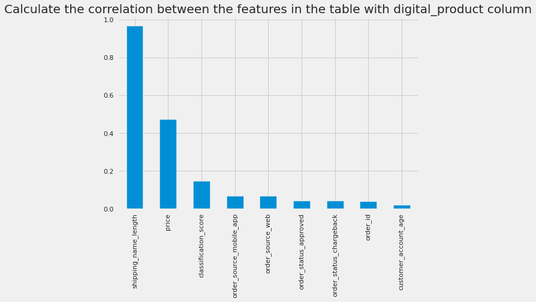

```python
abs(df_new.corrwith(df['digital_product'])).sort_values(ascending=False).plot(kind='bar')
plt.title("Calculate the correlation between the features in the table with digital_product column")
plt.show()
```

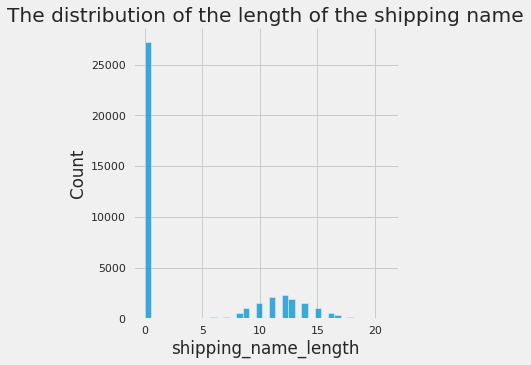

```python
sns.displot(df['shipping_name_length'])
plt.title("The distribution of the length of the shipping name")
plt.show()
```

**Distribution of the length of the shipping name to all tangible orders**

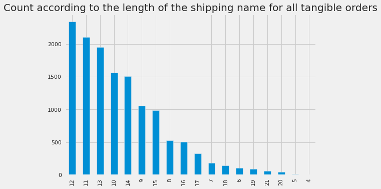

```python
plt.title('Count according to the length of the shipping name for all tangible orders')

df[df['digital_product']==False]['shipping_name_length'].value_counts().plot(kind='bar')
plt.show()
```

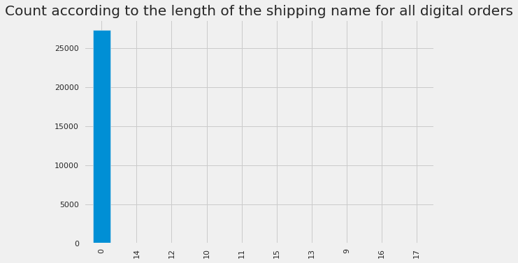

```python
plt.title('Count according to the length of the shipping name for all digital orders')
df[df['digital_product']==True]['shipping_name_length'].value_counts().plot(kind='bar')
plt.show()
```

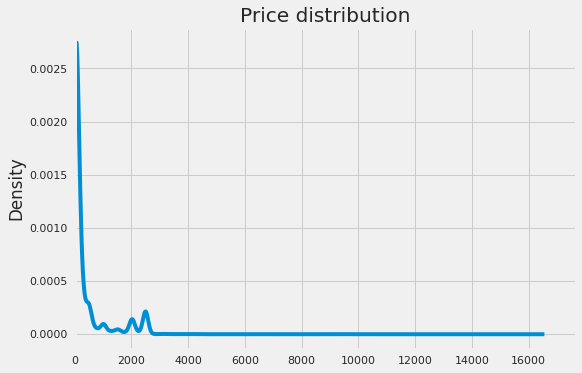

```python
df['price'].plot(kind='kde',xlim=(0))
plt.title("Price distribution")
plt.show()
```